# Cell-Cycle Scoring and Regression

#demonstrate how to mitigate the effects of cell cycle heterogeneity in scRNA-seq data by calculating cell cycle phase scores based on canonical markers, and regressing these out of the data during pre-processing. We demonstrate this on a dataset of murine hematopoietic progenitors (Nestorowa et al., Blood 2016) This is an [R Markdown](http://rmarkdown.rstudio.com) Notebook. When you execute code within the notebook, the results appear beneath the code.

```r
library(Seurat)

#read in file
#Read in the expression matrix The first row is a header row, the first column is rownames
exp.mat <- read.table(file = "/Users/surangijayasinghe/cell_cycle_vignette_files/nestorawa_forcellcycle_expressionMatrix.txt",
                      header = TRUE, as.is = TRUE, row.names = 1)

# A list of cell cycle markers, from Tirosh et al, 2015, is loaded with Seurat.  We can
# segregate this list into markers of G2/M phase and markers of S phase
s.genes <- cc.genes$s.genes
g2m.genes <- cc.genes$g2m.genes

# Create our Seurat object and complete the initalization steps
marrow <- CreateSeuratObject(counts = Matrix::Matrix(as.matrix(exp.mat), sparse = T))
marrow <- NormalizeData(marrow)
```

```
Normalizing layer: counts
```

```r
marrow <- FindVariableFeatures(marrow, selection.method = "vst")
```

```
Finding variable features for layer counts
```

```r
marrow <- ScaleData(marrow, features = rownames(marrow))
```

#If we run a PCA on our object, using the variable genes we found in FindVariableFeatures() above, we see that while most of the variance can be explained by lineage, PC8 and PC10 are split on cell-cycle genes including TOP2A and MKI67. We will attempt to regress this signal from the data, so that cell-cycle heterogeneity does not contribute to PCA or downstream analysis .

```r
marrow <- RunPCA(marrow, features = VariableFeatures(marrow), ndims.print = 6:10, nfeatures.print = 10)
```

```
PC_ 6
Positive:  LY6C2, AA467197, CYBB, MGST2, ITGB2, PF4, CD74, ATP1B1, GP1BB, TREM3
Negative:  SELL, ARL6IP1, CCL9, CD34, ADGRL4, BPIFC, NUSAP1, FAM64A, CD244, C030034L19RIK
PC_ 7
Positive:  HDC, CPA3, PGLYRP1, MS4A3, NKG7, UBE2C, CCNB1, NUSAP1, PLK1, FUT8
Negative:  F13A1, LY86, CFP, IRF8, CSF1R, TIFAB, IFI209, CCR2, TNS4, MS4A6C
PC_ 8
Positive:  NUSAP1, UBE2C, KIF23, PLK1, CENPF, FAM64A, CCNB1, H2AFX, ID2, CDC20
Negative:  WFDC17, SLC35D3, ADGRL4, VLDLR, CD33, H2AFY, P2RY14, IFI206, CCL9, CD34
PC_ 9
Positive:  IGKC, JCHAIN, LY6D, MZB1, CD74, IGLC2, FCRLA, IGKV4-50, IGHM, IGHV9-1
Negative:  SLC2A6, HBA-A1, HBA-A2, IGHV8-7, FCER1G, F13A1, HBB-BS, PLD4, HBB-BT, IGFBP4
PC_ 10
Positive:  CTSW, XKRX, PRR5L, RORA, MBOAT4, A630014C17RIK, ZFP105, COL9A3, CLEC2I, TRAT1
Negative:  H2AFX, FAM64A, ZFP383, NUSAP1, CDC25B, CENPF, GBP10, TOP2A, GBP6, GFRA1
```

#DimHeatmap provides a useful tool for exploring the relationships between gene expression and specific dimensions captured by dimensionality reduction techniques in scRNA-seq data analysis.

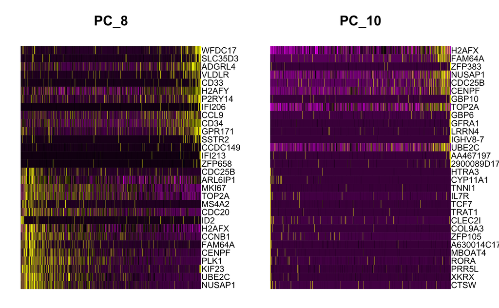

```r
DimHeatmap(marrow, dims = c(8, 10))
```

#Assign Cell-Cycle Scores #CellCycleScoring() function, which stores S and G2/M scores in object meta data, along with the predicted classification of each cell in either G2M, S or G1 phase. CellCycleScoring() can also set the identity of the Seurat object to the cell-cycle phase by passing set.ident = TRUE (the original identities are stored as old.ident). Please note that Seurat does not use the discrete classifications (G2M/G1/S) in downstream cell cycle regression. Instead, it uses the quantitative scores for G2M and S phase. However, we provide our predicted classifications in case they are of interest.

```r
marrow <- CellCycleScoring(marrow, s.features = s.genes, g2m.features = g2m.genes, set.ident = TRUE)
# view cell cycle scores and phase assignments
head(marrow[[]])
```

|  | orig.ident | nCount_RNA | nFeature_RNA | S.Score | G2M.Score | Phase | old.ident |
| --- | --- | --- | --- | --- | --- | --- | --- |
| Prog_013 | Prog | 2563089 | 10211 | -0.14248691 | -0.4680395 | G1 | Prog |
| Prog_019 | Prog | 3030620 | 9991 | -0.16915786 | 0.5851766 | G2M | Prog |
| Prog_031 | Prog | 1293487 | 10192 | -0.34627038 | -0.3971879 | G1 | Prog |
| Prog_037 | Prog | 1357987 | 9599 | -0.44270212 | 0.6820229 | G2M | Prog |
| Prog_008 | Prog | 4079891 | 10540 | 0.55854051 | 0.1284359 | S | Prog |
| Prog_014 | Prog | 2569783 | 10788 | 0.07116218 | 0.3166073 | G2M | Prog |

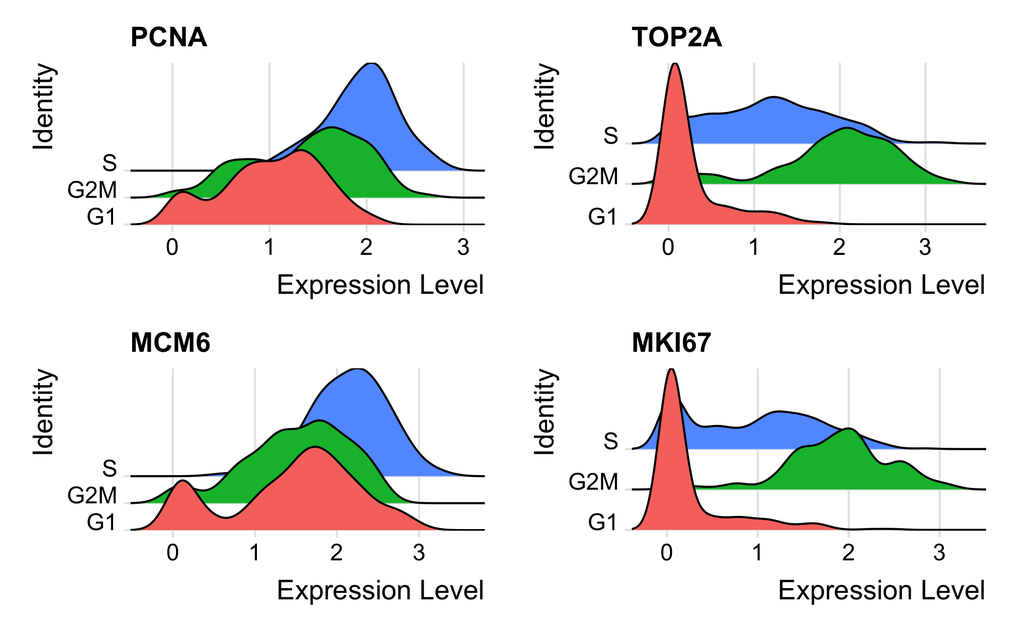

```r
# Visualize the distribution of cell cycle markers across
RidgePlot(marrow, features = c("PCNA", "TOP2A", "MCM6", "MKI67"), ncol = 2)
```

```r
# Running a PCA on cell cycle genes reveals, unsurprisingly, that cells separate entirely by
# phase
marrow <- RunPCA(marrow, features = c(s.genes, g2m.genes))
```

```
Warning: The following features were not available: MLF1IP, GMNN.Warning: You're computing too large a percentage of total singular values, use a standard svd instead.PC_ 1
Positive:  BIRC5, MKI67, HMGB2, CDK1, CDCA3, TOP2A, CKS1B, CDCA8, UBE2C, HMMR
       AURKB, TACC3, TUBB4B, KIF11, CKAP2L, RRM1, NUSAP1, TPX2, NUF2, CKS2
       AURKA, SMC4, CDC20, CENPA, RRM2, TYMS, BUB1, NCAPD2, CCNB2, CENPF
Negative:  UNG, MSH2, CASP8AP2, RFC2, CDCA7, CTCF, DTL, MCM6, CHAF1B, HELLS
       PSRC1, BRIP1, UBR7, WDR76, GAS2L3, POLD3, BLM, G2E3, MCM4, LBR
       MCM2, HN1, DSCC1, CKAP5, USP1, GINS2, ANP32E, PRIM1, RPA2, FAM64A
PC_ 2
Positive:  UBE2C, FAM64A, CENPF, NUSAP1, GAS2L3, KIF2C, KIF23, CENPE, HMMR, TPX2
       PSRC1, AURKA, KIF11, CKS2, CCNB2, CKAP5, CDC20, CDC25C, CENPA, CKAP2L
       G2E3, CDCA8, HN1, KIF20B, NEK2, BUB1, DLGAP5, MKI67, GTSE1, CDCA2
Negative:  UHRF1, MCM6, PCNA, MCM4, MCM2, UNG, MCM5, TIPIN, HELLS, RRM2
       SLBP, NASP, GINS2, RPA2, CDC6, DTL, PRIM1, CCNE2, CDCA7, DSCC1
       CHAF1B, RAD51, CDC45, POLA1, CLSPN, ATAD2, EXO1, RRM1, TYMS, RFC2
PC_ 3
Positive:  CENPA, CCNB2, CDC6, CCNE2, CDC20, FEN1, CDCA3, RANGAP1, TUBB4B, LBR
       RRM1, CKS2, CDCA8, BIRC5, NEK2, RRM2, NASP, RPA2, HMGB2, HMMR
       UBR7, SLBP, BUB1, KIF2C, TPX2, MCM2, MCM4, TIPIN, CKAP2, GINS2
Negative:  TOP2A, POLA1, RFC2, AURKB, CDCA2, FAM64A, BRIP1, NDC80, TYMS, NUSAP1
       CDK1, GAS2L3, KIF23, SMC4, HN1, WDR76, E2F8, TTK, ATAD2, PRIM1
       TMPO, KIF11, CBX5, ANLN, CTCF, CKAP2L, G2E3, CKAP5, HELLS, KIF20B
PC_ 4
Positive:  CDCA7, FAM64A, RFC2, GAS2L3, UNG, MSH2, CKAP2, KIF23, MCM2, MCM4
       HN1, HELLS, MCM5, CDC20, USP1, PSRC1, LBR, MCM6, G2E3, POLD3
       DTL, KIF2C, RPA2, CKAP5, CENPE, NEK2, DLGAP5, ECT2, CCNB2, UBR7
Negative:  E2F8, RAD51AP1, TYMS, RRM2, RAD51, BLM, CLSPN, MKI67, NDC80, BIRC5
       AURKB, CDCA3, ATAD2, NUF2, CDC6, TOP2A, POLA1, CKS2, ANLN, PCNA
       CCNE2, ANP32E, HMGB2, CTCF, TUBB4B, RRM1, CDC45, SLBP, KIF11, CENPA
PC_ 5
Positive:  FEN1, CHAF1B, HN1, CDC45, MSH2, AURKA, LBR, RAD51, CDCA2, GINS2
       AURKB, CDK1, UBE2C, DSCC1, GTSE1, TUBB4B, RRM2, KIF23, ANLN, G2E3
       EXO1, POLD3, TTK, RRM1, NUSAP1, TACC3, RAD51AP1, NEK2, CKAP2L, CDC20
Negative:  ANP32E, CASP8AP2, HELLS, TMPO, HMGB2, NCAPD2, WDR76, CTCF, CKS2, CCNB2
       POLA1, CKS1B, USP1, ATAD2, E2F8, SMC4, FAM64A, TIPIN, KIF20B, CDCA7
       UNG, SLBP, UBR7, MKI67, DTL, PSRC1, NASP, CENPA, CENPE, CDCA3
```

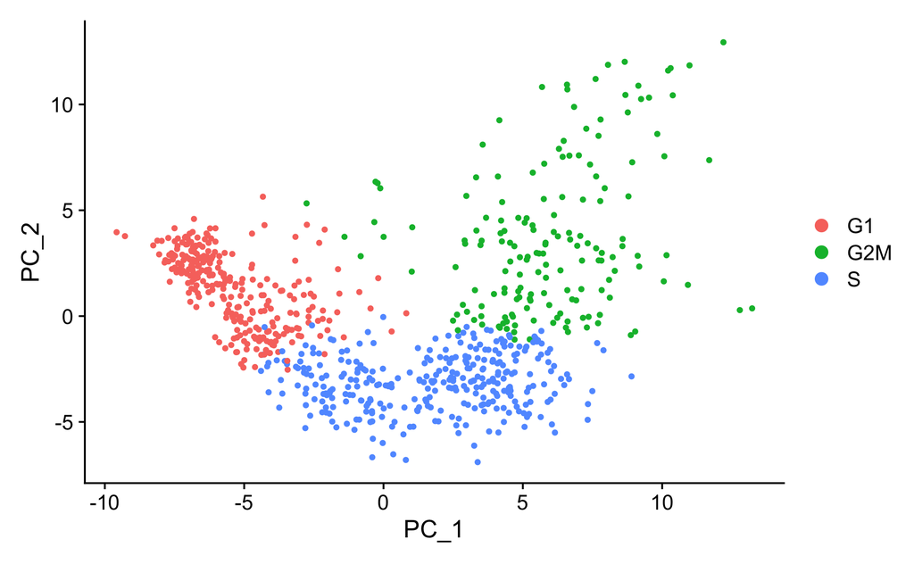

```r
DimPlot(marrow)
```

```r
library(ggplot2)
plot <- DimPlot(marrow) + theme(axis.title = element_text(size = 18), legend.text = element_text(size = 18)) +
    guides(colour = guide_legend(override.aes = list(size = 10)))
```

[output not shown]

```r
ggsave(filename = "../output/images/cell_cycle_vignette.jpg", height = 7, width = 12, plot = plot,
    quality = 50)
```

[output not shown]

[output not shown]

#Regress out cell cycle scores during data scaling #(‘regress out’) this source of heterogeneity from the data. For users of Seurat v1.4, this was implemented in RegressOut. However, as the results of this procedure are stored in the scaled data slot (therefore overwriting the output of ScaleData()), we now merge this functionality into the ScaleData() function itself.

```r
# Now, a PCA on the variable genes no longer returns components associated with cell cycle
marrow <- RunPCA(marrow, features = VariableFeatures(marrow), nfeatures.print = 10)
```

[output not shown]

```r
# When running a PCA on only cell cycle genes, cells no longer separate by cell-cycle phase
marrow <- RunPCA(marrow, features = c(s.genes, g2m.genes))
DimPlot(marrow)
```

[output not shown]

#Alternate Workflow #as an alternative, we suggest regressing out the difference between the G2M and S phase scores. This means that signals separating non-cycling cells and cycling cells will be maintained, but differences in cell cycle phase among proliferating cells (which are often uninteresting), will be regressed out of the data

```r
marrow$CC.Difference <- marrow$S.Score - marrow$G2M.Score
marrow <- ScaleData(marrow, vars.to.regress = "CC.Difference", features = rownames(marrow))
```

```r
# cell cycle effects strongly mitigated in PCA
marrow <- RunPCA(marrow, features = VariableFeatures(marrow), nfeatures.print = 10)
```

[output not shown]

```r
# when running a PCA on cell cycle genes, actively proliferating cells remain distinct from G1
# cells however, within actively proliferating cells, G2M and S phase cells group together
marrow <- RunPCA(marrow, features = c(s.genes, g2m.genes))
DimPlot(marrow)
```

[output not shown]